# Tayko-Software-Cataloger

Aditi Bhatnagar

2025-04-24

## Background

Tayko is a software catalog firm that sells games and educational software. It started out as a software manufacturer and later added third-party titles to its offerings. It has recently put together a revised collection of items in a new catalog, which it is preparing to roll out in a mailing.

Each catalog costs approximately $2 to mail (including printing, postage, and mailing costs). Estimate the gross profit that the firm could expect from the remaining 180,000 names if it selects them randomly from the pool.

**Step 1:** Load dataset

```r
Tayko.df <- read.csv("Tayko.csv",header=TRUE)
```

**Step 2:** Estimate Gross Profit

```r
cost_per_mail <- 2
response_rate <- 0.053
number_of_left_entries <- 180000
average_spend <- mean(Tayko.df[Tayko.df$Purchase==1,]$Spending)
gross_profit <- (average_spend * response_rate - cost_per_mail) * number_of_left_entries
gross_profit
```

```
## [1] 1598075
```

Partition the data randomly into a training set (800 records), validation set (700 records), and test set (500 records).

Develop a model for classifying a customer as a purchaser or nonpurchaser (Note: Use only the training set for running the model) We decided to attempt the following methods:

1. Step-wise logistic regression (using backward elimination)
2. Naive Bayes
3. KNN Model
4. CART

#### Approach 1: Step-wise logistic regression (using backward elimination)

**Step 1:** Load the data and partition the data randomly into a training set (800 records), validation set (700 records), and test set (500 records).

```r
Tayko.df <- read.csv("Tayko.csv",header=TRUE)
#dropping the unwanted column: last_update_days_ago and 1st_update_days_ago
Tayko.df <- Tayko.df[,-c(19,20)]

names(Tayko.df)
```

```
##  [1] "sequence_number" "US"              "source_a"        "source_c"
##  [5] "source_b"        "source_d"        "source_e"        "source_m"
##  [9] "source_o"        "source_h"        "source_r"        "source_s"
## [13] "source_t"        "source_u"        "source_p"        "source_x"
## [17] "source_w"        "Freq"            "Web.order"       "Gender.male"
## [21] "Address_is_res"  "Purchase"        "Spending"
```

```r
set.seed(6210)
all_rows <- rownames(Tayko.df)
train_rows <- sample(all_rows,800)
valid_rows <- sample(setdiff(all_rows,train_rows),700)
test_rows <- setdiff(all_rows,union(train_rows,valid_rows))

train.df <- Tayko.df[train_rows, ]
valid.df <- Tayko.df[valid_rows, ]
test.df <- Tayko.df[test_rows, ]

# Check partition sizes
cat("Training set size:", nrow(train.df), "\n")
```

```
## Training set size: 800
```

```r
cat("Validation set size:", nrow(valid.df), "\n")
```

```
## Validation set size: 700
```

```r
cat("Test set size:", nrow(test.df), "\n")
```

```
## Test set size: 500
```

**Step 2:** Run step-wise logistic regression using backward elimination to select the best subset of variables

```r
lr_model <- glm(Purchase ~ .-Spending- sequence_number, data = train.df, family = "binomial");
lr_model_b <- step(lr_model, direction = "backward");
```

```
## Start:  AIC=656.01
## Purchase ~ (sequence_number + US + source_a + source_c + source_b +
##     source_d + source_e + source_m + source_o + source_h + source_r +
##     source_s + source_t + source_u + source_p + source_x + source_w +
##     Freq + Web.order + Gender.male + Address_is_res + Spending) -
##     Spending - sequence_number
##
##                  Df Deviance    AIC
## - source_c        1   614.01 654.01
## - source_d        1   614.16 654.16
## - source_b        1   614.23 654.23
## - source_o        1   614.24 654.24
## - source_e        1   614.52 654.52
## - Gender.male     1   614.62 654.62
## - source_t        1   615.20 655.20
## - source_p        1   615.26 655.26
## - source_s        1   615.30 655.30
## - source_x        1   615.38 655.38
## - US              1   615.59 655.59
## - source_r        1   615.71 655.71
## <none>                614.01 656.01
## - Address_is_res  1   616.01 656.01
## - source_w        1   616.16 656.16
## - source_m        1   617.80 657.80
## - source_a        1   620.20 660.20
## - source_u        1   620.42 660.42
## - source_h        1   628.82 668.82
## - Web.order       1   646.16 686.16
## - Freq            1   925.93 965.93
##
## Step:  AIC=654.01
## Purchase ~ US + source_a + source_b + source_d + source_e + source_m +
##     source_o + source_h + source_r + source_s + source_t + source_u +
##     source_p + source_x + source_w + Freq + Web.order + Gender.male +
##     Address_is_res
##
##                  Df Deviance    AIC
## - source_d        1   614.36 652.36
## - source_o        1   614.37 652.37
## - source_b        1   614.46 652.46
```

[output cut: 243 more lines]

```
## - Freq       1   958.98 974.98
##
## Step:  AIC=644.33
## Purchase ~ source_a + source_m + source_h + source_u + source_w +
##     Freq + Web.order
##
##             Df Deviance    AIC
## <none>           628.33 644.33
## - source_w   1   630.80 644.80
## - source_m   1   632.17 646.17
## - source_u   1   644.13 658.13
## - source_a   1   646.54 660.54
## - Web.order  1   666.07 680.07
## - source_h   1   715.29 729.29
## - Freq       1   967.41 981.41
```

NOTE: We drop Spending because it leaks future information. At the time of mailing the catalog, Tayko would not know how much a customer will spend — only demographic and behavioral history are available. Spending and Purchase are highly correlated which could lead to incorrect high model accuracy and unrealistic predictions

**Step 3:** Create Confusion Matrixes for the validation set

**Default Cutoff (0.5)**

```r
#table(valid.df$Purchase)

# 1. Predict purchase probabilities on validation data
valid.prob <- predict(lr_model_b, newdata = valid.df, type = "response")

# 2. Classify purchasers vs non-purchasers with threshold 0.5
valid.class <- ifelse(valid.prob >= 0.5, 1, 0)

# 3. Confusion matrix for validation set
library(caret)
lg.cm <- confusionMatrix(as.factor(valid.class), as.factor(valid.df$Purchase), positive = "1")
print(lg.cm)
```

```
## Confusion Matrix and Statistics
##
##           Reference
## Prediction   0   1
##          0 253  48
##          1 104 295
##
##                Accuracy : 0.7829
##                  95% CI : (0.7504, 0.8129)
##     No Information Rate : 0.51
##     P-Value [Acc > NIR] : < 2.2e-16
##
##                   Kappa : 0.5669
##
##  Mcnemar's Test P-Value : 8.154e-06
##
##             Sensitivity : 0.8601
##             Specificity : 0.7087
##          Pos Pred Value : 0.7393
##          Neg Pred Value : 0.8405
##              Prevalence : 0.4900
##          Detection Rate : 0.4214
##    Detection Prevalence : 0.5700
##       Balanced Accuracy : 0.7844
##
##        'Positive' Class : 1
##
```

**What if the cut off was at 0.8?**

```r
# 1. Predict purchase probabilities on validation data
valid.prob1 <- predict(lr_model_b, newdata = valid.df, type = "response")

# 2. Classify purchasers vs non-purchasers with threshold 0.5
valid.class1 <- ifelse(valid.prob >= 0.8, 1, 0)

# 3. Confusion matrix for validation set
library(caret)
lg.cm1 <- confusionMatrix(as.factor(valid.class1), as.factor(valid.df$Purchase), positive = "1")
print(lg.cm1)
```

```
## Confusion Matrix and Statistics
##
##           Reference
## Prediction   0   1
##          0 343 170
##          1  14 173
##
##                Accuracy : 0.7371
##                  95% CI : (0.7029, 0.7694)
##     No Information Rate : 0.51
##     P-Value [Acc > NIR] : < 2.2e-16
##
##                   Kappa : 0.4693
##
##  Mcnemar's Test P-Value : < 2.2e-16
##
##             Sensitivity : 0.5044
##             Specificity : 0.9608
##          Pos Pred Value : 0.9251
##          Neg Pred Value : 0.6686
##              Prevalence : 0.4900
##          Detection Rate : 0.2471
##    Detection Prevalence : 0.2671
##       Balanced Accuracy : 0.7326
##
##        'Positive' Class : 1
##
```

**What if the cut off was at 0.2?**

```r
# 1. Predict purchase probabilities on validation data
valid.prob2 <- predict(lr_model_b, newdata = valid.df, type = "response")

# 2. Classify purchasers vs non-purchasers with threshold 0.5
valid.class2 <- ifelse(valid.prob >= 0.2, 1, 0)

# 3. Confusion matrix for validation set
library(caret)
lg.cm2 <- confusionMatrix(as.factor(valid.class2), as.factor(valid.df$Purchase), positive = "1")
print(lg.cm2)
```

```
## Confusion Matrix and Statistics
##
##           Reference
## Prediction   0   1
##          0 166   0
##          1 191 343
##
##                Accuracy : 0.7271
##                  95% CI : (0.6925, 0.7598)
##     No Information Rate : 0.51
##     P-Value [Acc > NIR] : < 2.2e-16
##
##                   Kappa : 0.46
##
##  Mcnemar's Test P-Value : < 2.2e-16
##
##             Sensitivity : 1.0000
##             Specificity : 0.4650
##          Pos Pred Value : 0.6423
##          Neg Pred Value : 1.0000
##              Prevalence : 0.4900
##          Detection Rate : 0.4900
##    Detection Prevalence : 0.7629
##       Balanced Accuracy : 0.7325
##
##        'Positive' Class : 1
##
```

**Step 4:** Plot the Lift Chart

```r
# Load the gains package
library(gains)

# 1. Predict probabilities on the validation set
pred.prob <- predict(lr_model_b, newdata = valid.df, type = "response")

# 2. Create the gain object
gain <- gains(actual = valid.df$Purchase,
              predicted = pred.prob,
              groups = 100)
```

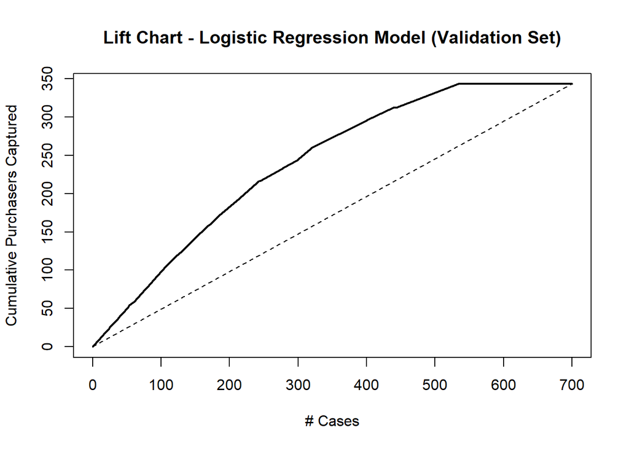

```r
# 3. Plot the Lift Chart
plot(c(0, gain$cume.pct.of.total * sum(valid.df$Purchase)) ~ c(0, gain$cume.obs),
     xlab = "# Cases",
     ylab = "Cumulative Purchasers Captured",
     main = "Lift Chart - Logistic Regression Model (Validation Set)",
     type = "l",
     lwd = 2)

# 4. Add the baseline (random model)
lines(c(0, sum(valid.df$Purchase)) ~ c(0, dim(valid.df)[1]), lty = 2)
```

#### Approach 2: Naive Bayes

**Step 1:** Load the data and partition the data randomly into a training set (800 records), validation set (700 records), and test set (500 records).

```r
Tayko.df <- read.csv("Tayko.csv",header=TRUE)
#dropping the unwanted column: last_update_days_ago and 1st_update_days_ago
Tayko.df <- Tayko.df[,-c(19,20)]

names(Tayko.df)
```

```
##  [1] "sequence_number" "US"              "source_a"        "source_c"
##  [5] "source_b"        "source_d"        "source_e"        "source_m"
##  [9] "source_o"        "source_h"        "source_r"        "source_s"
## [13] "source_t"        "source_u"        "source_p"        "source_x"
## [17] "source_w"        "Freq"            "Web.order"       "Gender.male"
## [21] "Address_is_res"  "Purchase"        "Spending"
```

```r
set.seed(6210)
all_rows <- rownames(Tayko.df)
train_rows <- sample(all_rows,800)
valid_rows <- sample(setdiff(all_rows,train_rows),700)
test_rows <- setdiff(all_rows,union(train_rows,valid_rows))

train.df <- Tayko.df[train_rows, ]
valid.df <- Tayko.df[valid_rows, ]
test.df <- Tayko.df[test_rows, ]

# Check partition sizes
cat("Training set size:", nrow(train.df), "\n")
```

```
## Training set size: 800
```

```r
cat("Validation set size:", nrow(valid.df), "\n")
```

```
## Validation set size: 700
```

```r
cat("Test set size:", nrow(test.df), "\n")
```

```
## Test set size: 500
```

**Step 2:** Build Naive Bayes model on training set

```r
# 0. Drop 'Spending' from training and validation sets (if not already done)
train.nb <- train.df[ , !(names(train.df) %in% c("Spending", "sequence_number")) ]
valid.nb <- valid.df[ , !(names(valid.df) %in% c("Spending", "sequence_number")) ]

# 1. Build Naive Bayes model on training set
library(e1071)
nb_model <- naiveBayes(factor(Purchase) ~ ., data = train.nb)
nb_model
```

```
##
## Naive Bayes Classifier for Discrete Predictors
##
## Call:
## naiveBayes.default(x = X, y = Y, laplace = laplace)
##
## A-priori probabilities:
## Y
##       0       1
## 0.48875 0.51125
##
## Conditional probabilities:
##    US
## Y        [,1]      [,2]
##   0 0.7851662 0.4112332
##   1 0.8459658 0.3614237
##
##    source_a
## Y         [,1]      [,2]
##   0 0.05626598 0.2307299
##   1 0.21026895 0.4079987
##
##    source_c
## Y         [,1]      [,2]
##   0 0.06905371 0.2538703
##   1 0.04889976 0.2159226
##
##    source_b
## Y         [,1]      [,2]
##   0 0.10230179 0.3034330
##   1 0.03422983 0.1820417
##
##    source_d
## Y         [,1]      [,2]
##   0 0.04092072 0.1983604
##   1 0.05378973 0.2258786
##
##    source_e
## Y        [,1]      [,2]
##   0 0.1892583 0.3922156
```

[output cut: 56 more lines]

```
##
##    Web.order
## Y        [,1]      [,2]
##   0 0.2864450 0.4526791
##   1 0.5427873 0.4987760
##
##    Gender.male
## Y        [,1]      [,2]
##   0 0.5575448 0.4973139
##   1 0.5281174 0.4998202
##
##    Address_is_res
## Y        [,1]      [,2]
##   0 0.2327366 0.4231172
##   1 0.2444988 0.4303160
```

**Step 3:** Predict probabilities on validation set

```r
nb_valid.prob <- predict(nb_model, newdata = valid.nb, type = "raw")[,2]  # Get probability for purchaser (class 1)
```

**Step 4:** Confusion Matrix on validation set

```r
library(caret)

# Classify using 0.5 threshold
nb_valid.class <- ifelse(nb_valid.prob >= 0.5, 1, 0)
nb.cm <- confusionMatrix(factor(nb_valid.class),factor(valid.nb$Purchase), positive = "1")
print(nb.cm)
```

```
## Confusion Matrix and Statistics
##
##           Reference
## Prediction   0   1
##          0 259 107
##          1  98 236
##
##                Accuracy : 0.7071
##                  95% CI : (0.6719, 0.7406)
##     No Information Rate : 0.51
##     P-Value [Acc > NIR] : <2e-16
##
##                   Kappa : 0.4137
##
##  Mcnemar's Test P-Value : 0.5763
##
##             Sensitivity : 0.6880
##             Specificity : 0.7255
##          Pos Pred Value : 0.7066
##          Neg Pred Value : 0.7077
##              Prevalence : 0.4900
##          Detection Rate : 0.3371
##    Detection Prevalence : 0.4771
##       Balanced Accuracy : 0.7068
##
##        'Positive' Class : 1
##
```

**Step 5**: Plot The Lift Chart

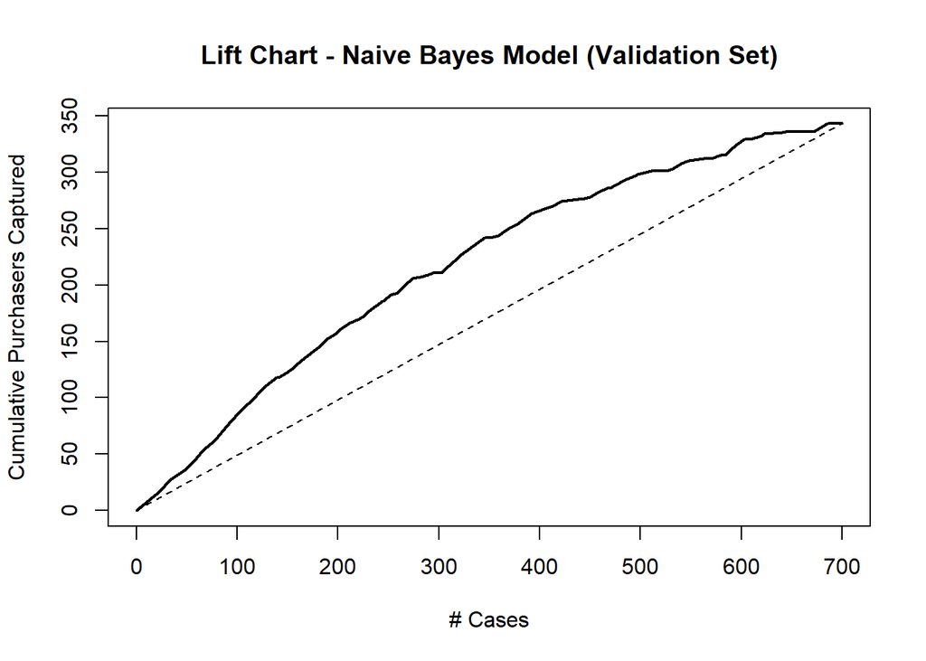

```r
library(gains)

nb_gain <- gains(actual = valid.nb$Purchase, predicted = nb_valid.prob, groups = 100)

plot(c(0, nb_gain$cume.pct.of.total * sum(valid.nb$Purchase)) ~ c(0, nb_gain$cume.obs),
     xlab = "# Cases",
     ylab = "Cumulative Purchasers Captured",
     main = "Lift Chart - Naive Bayes Model (Validation Set)",
     type = "l",
     lwd = 2)

lines(c(0, sum(valid.nb$Purchase)) ~ c(0, dim(valid.nb)[1]), lty = 2)
```

#### Approach 3: KNN Model

**Step 1:** Load the data and partition the data randomly into a training set (800 records), validation set (700 records), and test set (500 records).

```r
Tayko.df <- read.csv("Tayko.csv",header=TRUE)
names(Tayko.df)
```

```
##  [1] "sequence_number"      "US"                   "source_a"
##  [4] "source_c"             "source_b"             "source_d"
##  [7] "source_e"             "source_m"             "source_o"
## [10] "source_h"             "source_r"             "source_s"
## [13] "source_t"             "source_u"             "source_p"
## [16] "source_x"             "source_w"             "Freq"
## [19] "last_update_days_ago" "X1st_update_days_ago" "Web.order"
## [22] "Gender.male"          "Address_is_res"       "Purchase"
## [25] "Spending"
```

```r
set.seed(6210)
all_rows <- rownames(Tayko.df)
train_rows <- sample(all_rows,800)
valid_rows <- sample(setdiff(all_rows,train_rows),700)
test_rows <- setdiff(all_rows,union(train_rows,valid_rows))

train.df <- Tayko.df[train_rows, ]
valid.df <- Tayko.df[valid_rows, ]
test.df <- Tayko.df[test_rows, ]

# Check partition sizes
cat("Training set size:", nrow(train.df), "\n")
```

```
## Training set size: 800
```

```r
cat("Validation set size:", nrow(valid.df), "\n")
```

```
## Validation set size: 700
```

```r
cat("Test set size:", nrow(test.df), "\n")
```

```
## Test set size: 500
```

**Step 2:** Normalize Necessary Columns

```r
train.norm <- train.df
valid.norm <- valid.df
full.norm <- Tayko.df

predictor.cols <- setdiff(names(Tayko.df), c("Purchase", "Spending", "sequence_number"))

norm.values <- preProcess(train.df[, predictor.cols], method=c("center", "scale"))

train.norm[, predictor.cols] <- predict(norm.values, train.df[, predictor.cols])
valid.norm[, predictor.cols] <- predict(norm.values, valid.df[, predictor.cols])
full.norm[, predictor.cols]  <- predict(norm.values, Tayko.df[, predictor.cols])
```

**Step 3:** Find the best K-Value

```r
library(FNN)
# Prepare to store accuracy for each value of k
accuracy.df <- data.frame(k =1:20, accuracy = rep(0, 20))

# Loop over k values from 1 to 20
for (i in 1:20) {
  knn.pred <- knn(train = train.norm[, predictor.cols],
                  test  = valid.norm[, predictor.cols],
                  cl    = train.norm$Purchase,
                  k     = i)

# store the accuracy
accuracy.df[i, 2] <- confusionMatrix(as.factor(knn.pred),as.factor(valid.norm$Purchase))$overall["Accuracy"]
}

#store theaccuracy table
print(accuracy.df)
```

```
##     k  accuracy
## 1   1 0.7271429
## 2   2 0.6957143
## 3   3 0.7342857
## 4   4 0.7042857
## 5   5 0.7114286
## 6   6 0.7071429
## 7   7 0.7071429
## 8   8 0.7142857
## 9   9 0.7100000
## 10 10 0.6985714
## 11 11 0.6928571
## 12 12 0.6871429
## 13 13 0.6928571
## 14 14 0.6971429
## 15 15 0.6842857
## 16 16 0.6914286
## 17 17 0.6914286
## 18 18 0.7000000
## 19 19 0.7014286
## 20 20 0.7028571
```

**Step 4:** Display Confusion Matrix

```r
optimal.k <- 3

# Generate predictions for the validation set using k = 3
knn.pred <- knn(train = train.norm[, predictor.cols],
                test  = valid.norm[, predictor.cols],
                cl    = train.norm$Purchase,
                k     = optimal.k)

# Display full confusion matrix
knn.cm <- confusionMatrix(as.factor(knn.pred),
                as.factor(valid.norm$Purchase),
                positive = "1")

print(knn.cm)
```

```
## Confusion Matrix and Statistics
##
##           Reference
## Prediction   0   1
##          0 260  89
##          1  97 254
##
##                Accuracy : 0.7343
##                  95% CI : (0.6999, 0.7667)
##     No Information Rate : 0.51
##     P-Value [Acc > NIR] : <2e-16
##
##                   Kappa : 0.4686
##
##  Mcnemar's Test P-Value : 0.6078
##
##             Sensitivity : 0.7405
##             Specificity : 0.7283
##          Pos Pred Value : 0.7236
##          Neg Pred Value : 0.7450
##              Prevalence : 0.4900
##          Detection Rate : 0.3629
##    Detection Prevalence : 0.5014
##       Balanced Accuracy : 0.7344
##
##        'Positive' Class : 1
##
```

#### Approach #4: CART

**Step 1:** Load the data and partition the data randomly into a training set (800 records), validation set (700 records), and test set (500 records).

```r
Tayko.df <- read.csv("Tayko.csv",header=TRUE)

# Eliminate "sequence_number" & "Spending" variable. "Spending" is related(homogeneous) to the "Purchase" column, potentially leading to overfitting.
Tayko.df <- read.csv("Tayko.csv",header=TRUE)
Tayko.df <- Tayko.df[ , -c(1,19,20,25)]
head(Tayko.df)
```

```
##   US source_a source_c source_b source_d source_e source_m source_o source_h
## 1  1        0        0        1        0        0        0        0        0
## 2  1        0        0        0        0        1        0        0        0
## 3  1        0        0        0        0        0        0        0        0
## 4  1        0        1        0        0        0        0        0        0
## 5  1        0        1        0        0        0        0        0        0
## 6  1        0        0        0        0        0        0        0        0
##   source_r source_s source_t source_u source_p source_x source_w Freq Web.order
## 1        0        0        0        0        0        0        0    2         1
## 2        0        0        0        0        0        0        0    0         1
## 3        0        0        1        0        0        0        0    2         0
## 4        0        0        0        0        0        0        0    1         0
## 5        0        0        0        0        0        0        0    1         0
## 6        1        0        0        0        0        0        0    1         0
##   Gender.male Address_is_res Purchase
## 1           0              1        1
## 2           1              0        0
## 3           0              0        1
## 4           1              0        0
## 5           0              0        0
## 6           0              1        0
```

```r
set.seed(6210)

full_rows <- nrow(Tayko.df)

training_rows <- sample(full_rows, 800)
validation_rows <- sample(setdiff(full_rows, training_rows), 700)
test_rows <- sample(setdiff(full_rows, union(training_rows,validation_rows)), 500)
```

**Step 2:** Scale necessary columns

```r
# scale freq and spending field
columns_to_scale <- c("Freq")
Tayko.df[columns_to_scale] <- scale(Tayko.df[columns_to_scale])

dim(Tayko.df)
```

```
## [1] 2000   21
```

```r
head(Tayko.df)
```

```
##   US source_a source_c source_b source_d source_e source_m source_o source_h
## 1  1        0        0        1        0        0        0        0        0
## 2  1        0        0        0        0        1        0        0        0
## 3  1        0        0        0        0        0        0        0        0
## 4  1        0        1        0        0        0        0        0        0
## 5  1        0        1        0        0        0        0        0        0
## 6  1        0        0        0        0        0        0        0        0
##   source_r source_s source_t source_u source_p source_x source_w       Freq
## 1        0        0        0        0        0        0        0  0.4147288
## 2        0        0        0        0        0        0        0 -1.0080115
## 3        0        0        1        0        0        0        0  0.4147288
## 4        0        0        0        0        0        0        0 -0.2966414
## 5        0        0        0        0        0        0        0 -0.2966414
## 6        1        0        0        0        0        0        0 -0.2966414
##   Web.order Gender.male Address_is_res Purchase
## 1         1           0              1        1
## 2         1           1              0        0
## 3         0           0              0        1
## 4         0           1              0        0
## 5         0           0              0        0
## 6         0           0              1        0
```

**Step 3:** Define and plot tree

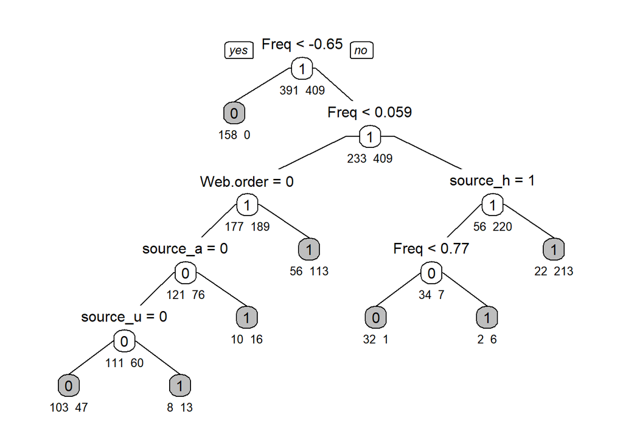

```r
# CART Model --- IMPURE TERMINAL NODES DUE TO MIX OF CLASSES IN THE NODES
library(rpart)
library(rpart.plot)
# Subset the data
training.df <- Tayko.df[training_rows, ]
validation.df <- Tayko.df[validation_rows, ]
test.df <- Tayko.df[test_rows, ]

# Define the tree
train_ct <- rpart(Purchase ~ ., data = training.df, method = "class")

# Plot the tree
prp(train_ct, type = 1, extra = 1, under = TRUE, split.font = 1, varlen = -10,
   box.col=ifelse(train_ct$frame$var == "<leaf>", 'gray', 'white'))
```

FULL GROWN TREE where cp = 0 to process until it reaches pure leaves

```r
# Define the tree
pure_ct <- rpart(Purchase ~ ., data = training.df, method = "class", cp = 0, minsplit = 1)

# Count the number of leaves
length(pure_ct$frame$var[pure_ct$frame$var == "<leaf>"])
```

```
## [1] 86
```

[figure not shown]

```r
# Plot the tree
prp(pure_ct, type = 1, extra = 1, under = TRUE, split.font = 1, varlen = -10,
   box.col=ifelse(train_ct$frame$var == "<leaf>", 'gray', 'white'))
```

```r
# Confusion Matrices and Accuracy for the Default and Full trees
default.ct.point.pred.train <- predict(train_ct, training.df, type = "class")

library(caret)
confusionMatrix(default.ct.point.pred.train, as.factor(training.df$Purchase), positive = "1")
```

```
## Confusion Matrix and Statistics
##
##           Reference
## Prediction   0   1
##          0 293  48
##          1  98 361
##
##                Accuracy : 0.8175
##                  95% CI : (0.789, 0.8437)
##     No Information Rate : 0.5112
##     P-Value [Acc > NIR] : < 2.2e-16
##
##                   Kappa : 0.6338
##
##  Mcnemar's Test P-Value : 5.008e-05
##
##             Sensitivity : 0.8826
##             Specificity : 0.7494
##          Pos Pred Value : 0.7865
##          Neg Pred Value : 0.8592
##              Prevalence : 0.5112
##          Detection Rate : 0.4512
##    Detection Prevalence : 0.5737
##       Balanced Accuracy : 0.8160
##
##        'Positive' Class : 1
##
```

**Step 4:** Prune for most optimal complexity

```r
# CART MODEL --- Pruning for most optimal complexity
optimal_ct <- rpart(Purchase ~ ., data = training.df, method ="class",
                    cp = 0.00001, minsplit = 5, xval = 5)

printcp(optimal_ct) # used to identify the most optimal ct with the lowest error
```

```
##
## Classification tree:
## rpart(formula = Purchase ~ ., data = training.df, method = "class",
##     cp = 1e-05, minsplit = 5, xval = 5)
##
## Variables actually used in tree construction:
##  [1] Address_is_res Freq           Gender.male    source_a       source_b
##  [6] source_c       source_d       source_e       source_h       source_m
## [11] source_r       source_u       source_w       US             Web.order
##
## Root node error: 391/800 = 0.48875
##
## n= 800
##
##            CP nsplit rel error  xerror     xstd
## 1  0.40409207      0   1.00000 1.00000 0.036160
## 2  0.06138107      1   0.59591 0.59591 0.032866
## 3  0.01534527      4   0.41176 0.41176 0.029003
## 4  0.01278772      5   0.39642 0.42199 0.029269
## 5  0.01023018      6   0.38363 0.41944 0.029203
## 6  0.00767263      7   0.37340 0.41432 0.029070
## 7  0.00511509      8   0.36573 0.40665 0.028867
## 8  0.00383632     12   0.34271 0.40153 0.028730
## 9  0.00255754     14   0.33504 0.39898 0.028660
## 10 0.00063939     28   0.29668 0.40153 0.028730
## 11 0.00001000     36   0.29156 0.41432 0.029070
```

```r
# CART MODEL --- Most optimal pruned model
pruned_ct <- prune(optimal_ct,
                   cp = optimal_ct$cptable[which.min(optimal_ct$cptable[,"xerror"]),"CP"])

length(pruned_ct$frame$var[pruned_ct$frame$var == "<leaf>"])
```

```
## [1] 15
```

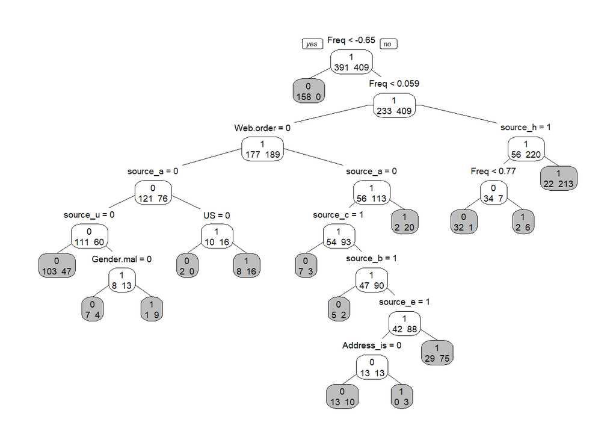

```r
prp(pruned_ct, type = 1, extra = 1, split.font = 1, varlen = -10,
    box.col=ifelse(pruned_ct$frame$var == "<leaf>", 'gray', 'white'))
```

```r
# Predict on the validation set using the pruned tree
pruned.pred <- predict(pruned_ct, newdata = validation.df, type = "class")

# Display the confusion matrix
cart_pruned.cm <- confusionMatrix(pruned.pred, as.factor(validation.df$Purchase), positive = "1")
print(cart_pruned.cm)
```

```
## Confusion Matrix and Statistics
##
##           Reference
## Prediction   0   1
##          0 291  63
##          1  59 287
##
##                Accuracy : 0.8257
##                  95% CI : (0.7955, 0.8531)
##     No Information Rate : 0.5
##     P-Value [Acc > NIR] : <2e-16
##
##                   Kappa : 0.6514
##
##  Mcnemar's Test P-Value : 0.7859
##
##             Sensitivity : 0.8200
##             Specificity : 0.8314
##          Pos Pred Value : 0.8295
##          Neg Pred Value : 0.8220
##              Prevalence : 0.5000
##          Detection Rate : 0.4100
##    Detection Prevalence : 0.4943
##       Balanced Accuracy : 0.8257
##
##        'Positive' Class : 1
##
```

#### Final Results

```r
# Extract metrics
model.names <- c("Logistic Regression", "Naive Bayes", "KNN", "CART (Pruned)")

accuracy <- c(lg.cm$overall["Accuracy"],
              nb.cm$overall["Accuracy"],
              knn.cm$overall["Accuracy"],
              cart_pruned.cm$overall["Accuracy"])

sensitivity <- c(lg.cm$byClass["Sensitivity"],
                 nb.cm$byClass["Sensitivity"],
                 knn.cm$byClass["Sensitivity"],
                 cart_pruned.cm$byClass["Sensitivity"])

specificity <- c(lg.cm$byClass["Specificity"],
                 nb.cm$byClass["Specificity"],
                 knn.cm$byClass["Specificity"],
                 cart_pruned.cm$byClass["Specificity"])

# Create summary data frame
comparison.df <- data.frame(
  Model = model.names,
  Accuracy = round(accuracy, 3),
  Sensitivity = round(sensitivity, 3),
  Specificity = round(specificity, 3)
)

print(comparison.df)
```

```
##                 Model Accuracy Sensitivity Specificity
## 1 Logistic Regression    0.783       0.860       0.709
## 2         Naive Bayes    0.707       0.688       0.725
## 3                 KNN    0.734       0.741       0.728
## 4       CART (Pruned)    0.826       0.820       0.831
```

**Step 1:** Load the data and partition the data randomly into a training set (800 records), validation set (700 records), and test set (500 records).

```r
Tayko.df <- read.csv("Tayko.csv",header=TRUE)
#dropping the unwanted column: last_update_days_ago and 1st_update_days_ago
Tayko.df <- Tayko.df[,-c(19,20)]

names(Tayko.df)
```

```
##  [1] "sequence_number" "US"              "source_a"        "source_c"
##  [5] "source_b"        "source_d"        "source_e"        "source_m"
##  [9] "source_o"        "source_h"        "source_r"        "source_s"
## [13] "source_t"        "source_u"        "source_p"        "source_x"
## [17] "source_w"        "Freq"            "Web.order"       "Gender.male"
## [21] "Address_is_res"  "Purchase"        "Spending"
```

```r
set.seed(6210)
all_rows <- rownames(Tayko.df)
train_rows <- sample(all_rows,800)
valid_rows <- sample(setdiff(all_rows,train_rows),700)
test_rows <- setdiff(all_rows,union(train_rows,valid_rows))

train.df <- Tayko.df[train_rows, ]
valid.df <- Tayko.df[valid_rows, ]
test.df <- Tayko.df[test_rows, ]

# Check partition sizes
cat("Training set size:", nrow(train.df), "\n")
```

```
## Training set size: 800
```

```r
cat("Validation set size:", nrow(valid.df), "\n")
```

```
## Validation set size: 700
```

```r
cat("Test set size:", nrow(test.df), "\n")
```

```
## Test set size: 500
```

**Step 2:** Scale necessary columns

```r
# scale freq and spending field
columns_to_scale <- c("Freq", "Spending")
Tayko.df[columns_to_scale] <- scale(Tayko.df[columns_to_scale])

dim(Tayko.df)
```

```
## [1] 2000   23
```

```r
head(Tayko.df)
```

```
##   sequence_number US source_a source_c source_b source_d source_e source_m
## 1               1  1        0        0        1        0        0        0
## 2               2  1        0        0        0        0        1        0
## 3               3  1        0        0        0        0        0        0
## 4               4  1        0        1        0        0        0        0
## 5               5  1        0        1        0        0        0        0
## 6               6  1        0        0        0        0        0        0
##   source_o source_h source_r source_s source_t source_u source_p source_x
## 1        0        0        0        0        0        0        0        0
## 2        0        0        0        0        0        0        0        0
## 3        0        0        0        0        1        0        0        0
## 4        0        0        0        0        0        0        0        0
## 5        0        0        0        0        0        0        0        0
## 6        0        0        1        0        0        0        0        0
##   source_w       Freq Web.order Gender.male Address_is_res Purchase   Spending
## 1        0  0.4147288         1           0              1        1  0.1358531
## 2        0 -1.0080115         1           1              0        0 -0.5494355
## 3        0  0.4147288         0           0              0        1  0.1304993
## 4        0 -0.2966414         0           1              0        0 -0.5494355
## 5        0 -0.2966414         0           0              0        0 -0.5494355
## 6        0 -0.2966414         0           0              1        0 -0.5494355
```

**Step 3**: Build linear regression model

```r
# Build linear regression model
lm.model <- lm(Spending ~ ., data = train.df)

# View summary (optional, shows significant predictors)
summary(lm.model)
```

```
##
## Call:
## lm(formula = Spending ~ ., data = train.df)
##
## Residuals:
##     Min      1Q  Median      3Q     Max
## -454.05  -50.28   -6.21   43.73 1220.39
##
## Coefficients:
##                   Estimate Std. Error t value Pr(>|t|)
## (Intercept)      -6.548833  24.632617  -0.266  0.79042
## sequence_number  -0.016746   0.007532  -2.223  0.02647 *
## US               -4.684594  11.665440  -0.402  0.68810
## source_a        -17.259184  24.771245  -0.697  0.48617
## source_c        -53.640009  27.634535  -1.941  0.05261 .
## source_b        -22.678505  26.767369  -0.847  0.39712
## source_d        -49.229530  29.275669  -1.682  0.09305 .
## source_e        -29.946161  23.690707  -1.264  0.20659
## source_m        -54.166103  41.524360  -1.304  0.19247
## source_o          0.720845  33.377032   0.022  0.98277
## source_h        -83.317698  29.749449  -2.801  0.00523 **
## source_r         31.791806  27.566523   1.153  0.24915
## source_s        -28.220454  29.769965  -0.948  0.34345
## source_t        -90.537888  38.225980  -2.368  0.01810 *
## source_u        -13.019375  25.147455  -0.518  0.60480
## source_p        -82.169945  58.742852  -1.399  0.16227
## source_x        -22.524028  38.899891  -0.579  0.56274
## source_w        -33.540497  24.501867  -1.369  0.17143
## Freq             89.371507   3.769946  23.706  < 2e-16 ***
## Web.order        -0.148904   9.128861  -0.016  0.98699
## Gender.male       4.438620   8.717380   0.509  0.61078
## Address_is_res  -56.715629  11.354943  -4.995 7.28e-07 ***
## Purchase         82.119486  10.833992   7.580 9.87e-14 ***
## ---
## Signif. codes:  0 '***' 0.001 '**' 0.01 '*' 0.05 '.' 0.1 ' ' 1
##
## Residual standard error: 121.8 on 777 degrees of freedom
## Multiple R-squared:  0.5973, Adjusted R-squared:  0.5859
## F-statistic: 52.38 on 22 and 777 DF,  p-value: < 2.2e-16
```

**Step 4**: Predict using validation set

```r
# Predict Spending for validation set
lm.pred <- predict(lm.model, newdata = valid.df)
```

#### Approach 2: Regression trees

**Step 1:** Load the data and partition the data randomly into a training set (800 records), validation set (700 records), and test set (500 records).

```r
Tayko.df <- read.csv("Tayko.csv",header=TRUE)
#dropping the unwanted column: last_update_days_ago and 1st_update_days_ago
Tayko.df <- Tayko.df[,-c(19,20)]

names(Tayko.df)
```

```
##  [1] "sequence_number" "US"              "source_a"        "source_c"
##  [5] "source_b"        "source_d"        "source_e"        "source_m"
##  [9] "source_o"        "source_h"        "source_r"        "source_s"
## [13] "source_t"        "source_u"        "source_p"        "source_x"
## [17] "source_w"        "Freq"            "Web.order"       "Gender.male"
## [21] "Address_is_res"  "Purchase"        "Spending"
```

```r
set.seed(6210)
all_rows <- rownames(Tayko.df)
train_rows <- sample(all_rows,800)
valid_rows <- sample(setdiff(all_rows,train_rows),700)
test_rows <- setdiff(all_rows,union(train_rows,valid_rows))

train.df <- Tayko.df[train_rows, ]
valid.df <- Tayko.df[valid_rows, ]
test.df <- Tayko.df[test_rows, ]

# Check partition sizes
cat("Training set size:", nrow(train.df), "\n")
```

```
## Training set size: 800
```

```r
cat("Validation set size:", nrow(valid.df), "\n")
```

```
## Validation set size: 700
```

```r
cat("Test set size:", nrow(test.df), "\n")
```

```
## Test set size: 500
```

**Step 2:** Scale necessary columns

```r
# scale freq and spending field
columns_to_scale <- c("Freq", "Spending")
Tayko.df[columns_to_scale] <- scale(Tayko.df[columns_to_scale])

dim(Tayko.df)
```

```
## [1] 2000   23
```

```r
head(Tayko.df)
```

```
##   sequence_number US source_a source_c source_b source_d source_e source_m
## 1               1  1        0        0        1        0        0        0
## 2               2  1        0        0        0        0        1        0
## 3               3  1        0        0        0        0        0        0
## 4               4  1        0        1        0        0        0        0
## 5               5  1        0        1        0        0        0        0
## 6               6  1        0        0        0        0        0        0
##   source_o source_h source_r source_s source_t source_u source_p source_x
## 1        0        0        0        0        0        0        0        0
## 2        0        0        0        0        0        0        0        0
## 3        0        0        0        0        1        0        0        0
## 4        0        0        0        0        0        0        0        0
## 5        0        0        0        0        0        0        0        0
## 6        0        0        1        0        0        0        0        0
##   source_w       Freq Web.order Gender.male Address_is_res Purchase   Spending
## 1        0  0.4147288         1           0              1        1  0.1358531
## 2        0 -1.0080115         1           1              0        0 -0.5494355
## 3        0  0.4147288         0           0              0        1  0.1304993
## 4        0 -0.2966414         0           1              0        0 -0.5494355
## 5        0 -0.2966414         0           0              0        0 -0.5494355
## 6        0 -0.2966414         0           0              1        0 -0.5494355
```

**Step 3**: Build and plot regression tree

```r
library(rpart)
library(rpart.plot)
library(forecast)
# Regression tree
reg.tree <- rpart(Spending ~ ., data = train.df, method = "anova")
```

**Step 4**: Plot the tree

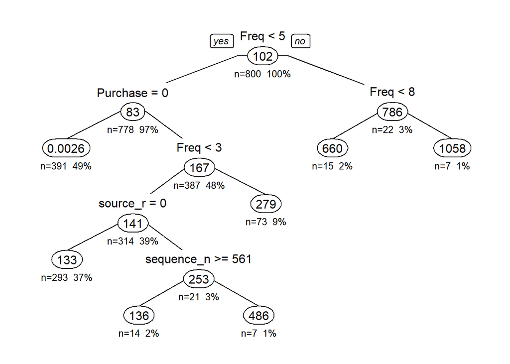

```r
# Plot tree
prp(reg.tree, type = 1, extra = 101, under = TRUE, split.font = 1, varlen = -10)
```

**Step 5**: Predict using validation set

```r
# Predict Spending for validation set
tree.pred <- predict(reg.tree, newdata = valid.df)

options(scipen=999, digits = 3)
accuracy(tree.pred, valid.df$Spending)
```

```
##              ME RMSE  MAE  MPE MAPE
## Test set -0.202  120 52.8 -Inf  Inf
```

```r
r2 <- cor(tree.pred, valid.df$Spending)^2
print(r2)
```

```
## [1] 0.585
```

#### Approach 3: Neural Network Analysis

**Step 1:** Load the data and partition the data randomly into a training set (800 records), validation set (700 records), and test set (500 records).

```r
Tayko.df <- read.csv("Tayko.csv",header=TRUE)
#dropping the unwanted column: last_update_days_ago and 1st_update_days_ago
Tayko.df <- Tayko.df[,-c(19,20)]

names(Tayko.df)
```

```
##  [1] "sequence_number" "US"              "source_a"        "source_c"
##  [5] "source_b"        "source_d"        "source_e"        "source_m"
##  [9] "source_o"        "source_h"        "source_r"        "source_s"
## [13] "source_t"        "source_u"        "source_p"        "source_x"
## [17] "source_w"        "Freq"            "Web.order"       "Gender.male"
## [21] "Address_is_res"  "Purchase"        "Spending"
```

```r
set.seed(6210)
all_rows <- rownames(Tayko.df)
train_rows <- sample(all_rows,800)
valid_rows <- sample(setdiff(all_rows,train_rows),700)
test_rows <- setdiff(all_rows,union(train_rows,valid_rows))

train.df <- Tayko.df[train_rows, ]
valid.df <- Tayko.df[valid_rows, ]
test.df <- Tayko.df[test_rows, ]

# Check partition sizes
cat("Training set size:", nrow(train.df), "\n")
```

```
## Training set size: 800
```

```r
cat("Validation set size:", nrow(valid.df), "\n")
```

```
## Validation set size: 700
```

```r
cat("Test set size:", nrow(test.df), "\n")
```

```
## Test set size: 500
```

**Step 2:** Scale necessary columns

```r
# scale freq and spending field
columns_to_scale <- c("Freq", "Spending")
Tayko.df[columns_to_scale] <- scale(Tayko.df[columns_to_scale])

dim(Tayko.df)
```

```
## [1] 2000   23
```

```r
head(Tayko.df)
```

```
##   sequence_number US source_a source_c source_b source_d source_e source_m
## 1               1  1        0        0        1        0        0        0
## 2               2  1        0        0        0        0        1        0
## 3               3  1        0        0        0        0        0        0
## 4               4  1        0        1        0        0        0        0
## 5               5  1        0        1        0        0        0        0
## 6               6  1        0        0        0        0        0        0
##   source_o source_h source_r source_s source_t source_u source_p source_x
## 1        0        0        0        0        0        0        0        0
## 2        0        0        0        0        0        0        0        0
## 3        0        0        0        0        1        0        0        0
## 4        0        0        0        0        0        0        0        0
## 5        0        0        0        0        0        0        0        0
## 6        0        0        1        0        0        0        0        0
##   source_w   Freq Web.order Gender.male Address_is_res Purchase Spending
## 1        0  0.415         1           0              1        1    0.136
## 2        0 -1.008         1           1              0        0   -0.549
## 3        0  0.415         0           0              0        1    0.130
## 4        0 -0.297         0           1              0        0   -0.549
## 5        0 -0.297         0           0              0        0   -0.549
## 6        0 -0.297         0           0              1        0   -0.549
```

**Step 3: Create Neural Network**

```r
library(neuralnet)
```

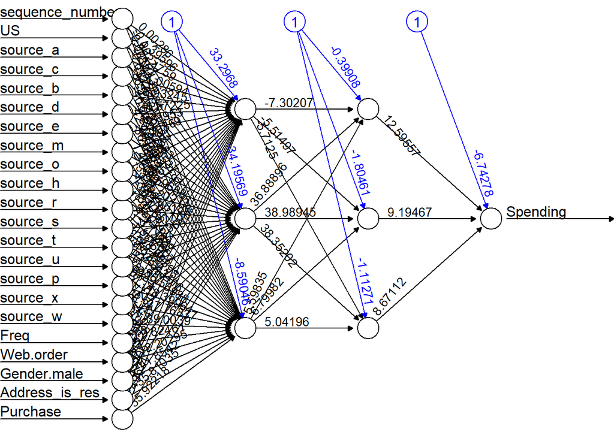

```r
library(caret)
library(scales)

nn <- neuralnet(Spending ~ .,
                data = train.df, linear.output = FALSE, hidden = c(3, 3),
                threshold=0.01)

plot(nn, rep="best")
```

```r
nn.results <- compute(nn, valid.df)
```

#### Final Results

```r
# Get R-squared for each model
lm.r2 <- cor(lm.pred, valid.df$Spending)^2
tree.r2 <- cor(tree.pred, valid.df$Spending)^2

# For neural network, get prediction on validation data
nn.pred <- compute(nn, valid.df)$net.result
nn.r2 <- cor(nn.pred, valid.df$Spending)^2

# Compute RMSE and MAE for each model
lm.rmse <- sqrt(mean((lm.pred - valid.df$Spending)^2))
tree.rmse <- sqrt(mean((tree.pred - valid.df$Spending)^2))
nn.rmse <- sqrt(mean((nn.pred - valid.df$Spending)^2))

lm.mae <- mean(abs(lm.pred - valid.df$Spending))
tree.mae <- mean(abs(tree.pred - valid.df$Spending))
nn.mae <- mean(abs(nn.pred - valid.df$Spending))

# Create expanded summary data frame
model.summary <- data.frame(
  Model = c("Linear Regression", "Regression Tree", "Neural Network"),
  R_squared = round(c(lm.r2, tree.r2, nn.r2), 3),
  RMSE = round(c(lm.rmse, tree.rmse, nn.rmse), 2),
  MAE = round(c(lm.mae, tree.mae, nn.mae), 2)
)

print(model.summary)
```

```
##               Model R_squared RMSE   MAE
## 1 Linear Regression     0.575  121  72.9
## 2   Regression Tree     0.585  120  52.8
## 3    Neural Network     0.327  211 102.8
```